# R For Data Science

### R - A Functional, Object Based Language

Everything that exists in R is an object

R promotes encapsulation - separate but related data are packaged together.

R classes are polymorphic - generic gunctions like plot and summary may have different methods for different objects or data structures

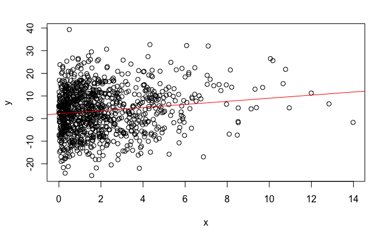

```r
plot(x,y)
abline(model, col = "red")
```

It is not much more difficult to draw more sophisticated looing simple plots using the either the additional plotting systems based on the lattice or ggplot2 graphic systems. yuu

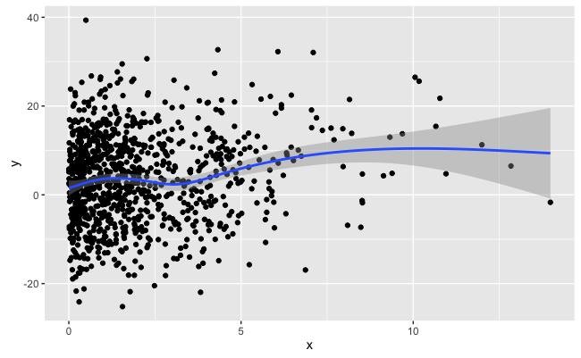

```r
library(ggplot2)
df <- data.frame(x,y)
ggplot(df, aes(x,y)) + geom_point() + geom_smooth()
```

### Functions

“A function is a group of instructions that takes inputs, uses them to compute other values, and returns the result” - Norm Matloff The Art of R Programming

Let’s write our own mean function

```r
pemax <- c(95,85,100,85,95,80,65,110,70,95,110,90,100,80,134) #some data
jmean <- function(x){
    m <- sum(x)/length(x)       # where is m?
    return(m)
}
jmean(pemax)
```

```
[1] 92.93333
```

Try again and improve the formatting

```r
jmean2 <- function(x){
    m <- round(sum(x)/length(x),2)
    return(m)
}
jmean2(pemax)
```

```
[1] 92.93
```

Why not give the user more control of the rounding process?  
The magic 3 dots … enable arguments to be passed to sub functions

```r
jmean3 <- function(x,...){
    m <- round(sum(x)/length(x),...)
    return(m)
}
#?round                     # look to see what parameters round is expecting
jmean3(pemax,3)
```

```
[1] 92.933
```

```r
jmean3(pemax)               # the default value for round is 0
```

```
[1] 93
```

```r
jmean3(pemax,1)
```

```
[1] 92.9
```

## Functions calling Functions

How about giving the user a choice about which rounding function to use?  
Look at the difference between round() and signif().

```r
pi
```

```
[1] 3.141593
```

```r
round(pi,4)
```

```
[1] 3.1416
```

```r
signif(pi,4)
```

```
[1] 3.142
```

This is the way to have one function call an other function

```r
jmean4 <- function(x,FUN,...){
    m <- FUN(sum(x)/length(x),...)
    return(m)
}
jmean4(pemax,round,4)
```

```
[1] 92.9333
```

```r
jmean4(pemax,signif,4)
```

```
[1] 92.93
```

### More Visualizations

In some cases, specialized packages implement plots that work with specific kinds of data. Here is a specialized financial plot rendered in just a few lines of code.

```r
library(quantmod)
# get S&P 500 data from FRED (St. Louis Fed)
sp500 <- na.omit(
  getSymbols(
    "SP500",
    src = "FRED",
    from = "1949-12-31",
    auto.assign = FALSE
  )
)
```

[output not shown]

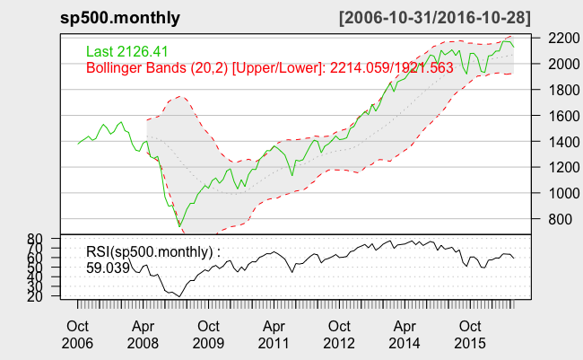

```r
sp500.monthly <- sp500[endpoints(sp500, on ="months")]
chartSeries(
  sp500.monthly,
  theme = chartTheme("white"),
  TA = c(addBBands(),addTA(RSI(sp500.monthly)))
)
```

### More sophisticated Graphics.

Here we use data on the overflow of the Nile river to illustrate the the kinds of visualizations that can be made with ggplot2 and Javascript.

```r
library(ggplot2)            # for plotting functions
# library(car)                # for the recode function, rc
library(reshape2)           # for melt function to build long form data frame
library(pracma)             # for Nile river data
data(nile)
head(nile)
```

|  | Year | Jan | Feb | Mar | Apr | May | Jun | Jul | Aug | Sep | Oct | Nov | Dec |
| --- | --- | --- | --- | --- | --- | --- | --- | --- | --- | --- | --- | --- | --- |
| 1 | 1871 | 2606 | 1992 | 1485 | 933 | 731 | 760 | 2475 | 8960 | 9953 | 6571 | 3522 | 2419 |
| 2 | 1872 | 1672 | 1033 | 728 | 605 | 560 | 879 | 3121 | 8811 | 10532 | 7952 | 4976 | 3102 |
| 3 | 1873 | 2187 | 1851 | 1235 | 756 | 556 | 1392 | 2296 | 7093 | 8410 | 5675 | 3070 | 2049 |
| 4 | 1874 | 1340 | 847 | 664 | 516 | 466 | 964 | 3061 | 10790 | 11805 | 8064 | 4282 | 2904 |
| 5 | 1875 | 2210 | 1686 | 1060 | 771 | 638 | 698 | 2396 | 9259 | 10455 | 7691 | 4436 | 2830 |
| 6 | 1876 | 2116 | 1791 | 1441 | 945 | 724 | 887 | 3106 | 8811 | 11072 | 6757 | 3788 | 2523 |

```r
# Many data frames arenaturally in “wide” form. To plot this data with ggplot2 te data must be transformed into “long” form.
nile_dat <- melt(nile,idvar="Year",measure.vars=month.abb,variable.name="Month",value.name="Obs")
nile_dat_long <- nile_dat[with(nile_dat,order(Year,Month)),]         # sort
# Make a date variable
nile_dat_long$Date <- paste(with(nile_dat_long,Date<- paste(Month,"-","15","-",as.character(Year),sep="")))
nile_dat_long$Date <- as.Date(nile_dat_long$Date,format="%b-%d-%Y")
head(nile_dat_long)
```

|  | Year | Month | Obs | Date |
| --- | --- | --- | --- | --- |
| 1 | 1871 | Jan | 2606 | 1871-01-15 |
| 115 | 1871 | Feb | 1992 | 1871-02-15 |
| 229 | 1871 | Mar | 1485 | 1871-03-15 |
| 343 | 1871 | Apr | 933 | 1871-04-15 |
| 457 | 1871 | May | 731 | 1871-05-15 |
| 571 | 1871 | Jun | 760 | 1871-06-15 |

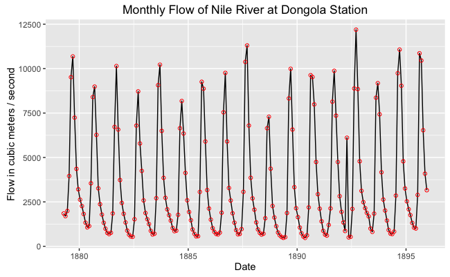

```r
# Plot the time series
p <- ggplot(nile_dat_long[100:300,],aes(x=Date,y=Obs))
p + geom_line() + geom_point(shape=1,col="red") +
  ylab("Flow in cubic meters / second") +
  ggtitle("Monthly Flow of Nile River at Dongola Station")
```

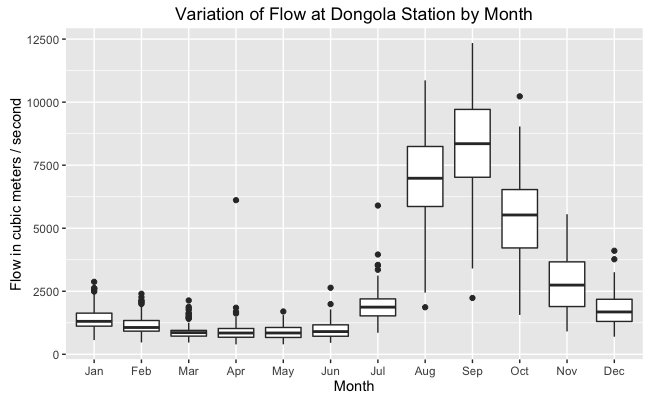

```r
# Boxplots of monthly flows
b <- ggplot(nile_dat_long,aes(factor(Month),Obs))
b + geom_boxplot() +
  xlab("Month") +
  ylab("Flow in cubic meters / second") +
  ggtitle("Variation of Flow at Dongola Station by Month")
```

### Create an interactive graph with a Javascript library

```r
library(xts)
library(dygraphs)
# Make into a time series object
nile_ts <- xts(nile_dat_long$Obs,
               order.by=nile_dat_long$Date,
               frequency=12,start=c(1871,1))
# Plot wit htmlwidget dygraph
dygraph(nile_ts,ylab="cubic m / s",
        main="Nile Monthly Flow Data") %>%
  dySeries("V1",label="Flow") %>%
  dyRangeSelector(dateWindow = c("1871-01-01","1984-12-01"))
```

[interactive chart not shown]